# lab4

## Task 5

```r
#Summarizing quad.lm
summary(quad.lm)
```

```
##
## Call:
## lm(formula = Height ~ BHDiameter + I(BHDiameter^2), data = spruce.df)
##
## Residuals:
##     Min      1Q  Median      3Q     Max
## -3.2966 -0.6245 -0.0707  0.7442  3.2541
##
## Coefficients:
##                  Estimate Std. Error t value Pr(>|t|)
## (Intercept)      0.860896   2.205022   0.390 0.698731
## BHDiameter       1.469592   0.243786   6.028 8.88e-07 ***
## I(BHDiameter^2) -0.027457   0.006635  -4.138 0.000227 ***
## ---
## Signif. codes:  0 '***' 0.001 '**' 0.01 '*' 0.05 '.' 0.1 ' ' 1
##
## Residual standard error: 1.382 on 33 degrees of freedom
## Multiple R-squared:  0.7741, Adjusted R-squared:  0.7604
## F-statistic: 56.55 on 2 and 33 DF,  p-value: 2.182e-11
```

```r
#Making interval estimates for mentioned variables
quad.lm$coef[1] + c(-2.205022,2.205022)
```

```
## [1] -1.344126  3.065918
```

```r
quad.lm$coef[2] + c(-0.243786,0.243786)
```

```
## [1] 1.225806 1.713378
```

```r
quad.lm$coef[3] + c(-0.006635,0.006635)
```

```
## [1] -0.03409226 -0.02082226
```

```r
#predicting Height of spruce for mentioned values
predict(quad.lm, data.frame(BHDiameter=c(15,18,20)))
```

```
##        1        2        3
## 16.72690 18.41740 19.26984
```

```r
#comparing two models with anova
anova(quad.lm)
```

```
## Analysis of Variance Table
##
## Response: Height
##                 Df  Sum Sq Mean Sq F value    Pr(>F)
## BHDiameter       1 183.245 183.245  95.975 2.701e-11 ***
## I(BHDiameter^2)  1  32.696  32.696  17.125 0.0002269 ***
## Residuals       33  63.007   1.909
## ---
## Signif. codes:  0 '***' 0.001 '**' 0.01 '*' 0.05 '.' 0.1 ' ' 1
```

```r
anova(spruce.lm)
```

```
## Analysis of Variance Table
##
## Response: Height
##            Df  Sum Sq Mean Sq F value    Pr(>F)
## BHDiameter  1 183.245 183.245  65.101 2.089e-09 ***
## Residuals  34  95.703   2.815
## ---
## Signif. codes:  0 '***' 0.001 '**' 0.01 '*' 0.05 '.' 0.1 ' ' 1
```

```r
#Finding TSS,MSS,RSS,and MSS/TSS
RSS=with(spruce.df, sum((Height-quad.fit)^2))
RSS
```

```
## [1] 63.00683
```

```r
MSS = with(spruce.df, sum((quad.fit-mean(Height))^2))
MSS
```

```
## [1] 215.9407
```

```r
TSS = with(spruce.df, sum((Height-mean(Height))^2))
TSS
```

```
## [1] 278.9475
```

```r
MSS/TSS
```

```
## [1] 0.7741266
```

The asked for values are as follows: 0.860896, 1.469592, and -0.027457.

Equation of fitted line: 0.86089580 +1.46959217*x -0.02745726*x^2 where x is BHDiameter.

Multiple R-Squared is .7741. It’s value is also higher than in the previous model. An indication of a better fit.

In this context, the multiple R-squared tells us that our model is providing a great prediction of height based on BHDiameter.

This model explains the most variability in Height.

## Task 6

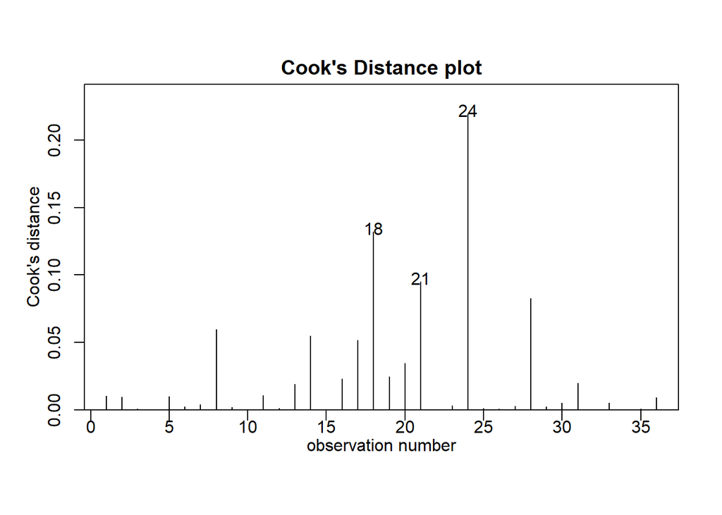

```r
cooks20x(quad.lm)
```

```r
#Now remove the 24th datum and reanalyze data
quad2.lm=lm(Height~BHDiameter + I(BHDiameter^2) , data=spruce.df[-24,])
summary(quad2.lm)
```

```
##
## Call:
## lm(formula = Height ~ BHDiameter + I(BHDiameter^2), data = spruce.df[-24,
##     ])
##
## Residuals:
##      Min       1Q   Median       3Q      Max
## -3.11233 -0.48227  0.01253  0.71727  2.59146
##
## Coefficients:
##                  Estimate Std. Error t value Pr(>|t|)
## (Intercept)     -0.341500   2.068479  -0.165     0.87
## BHDiameter       1.564793   0.226102   6.921 7.78e-08 ***
## I(BHDiameter^2) -0.029242   0.006114  -4.782 3.74e-05 ***
## ---
## Signif. codes:  0 '***' 0.001 '**' 0.01 '*' 0.05 '.' 0.1 ' ' 1
##
## Residual standard error: 1.266 on 32 degrees of freedom
## Multiple R-squared:  0.8159, Adjusted R-squared:  0.8044
## F-statistic: 70.91 on 2 and 32 DF,  p-value: 1.74e-12
```

```r
summary(quad.lm)
```

```
##
## Call:
## lm(formula = Height ~ BHDiameter + I(BHDiameter^2), data = spruce.df)
##
## Residuals:
##     Min      1Q  Median      3Q     Max
## -3.2966 -0.6245 -0.0707  0.7442  3.2541
##
## Coefficients:
##                  Estimate Std. Error t value Pr(>|t|)
## (Intercept)      0.860896   2.205022   0.390 0.698731
## BHDiameter       1.469592   0.243786   6.028 8.88e-07 ***
## I(BHDiameter^2) -0.027457   0.006635  -4.138 0.000227 ***
## ---
## Signif. codes:  0 '***' 0.001 '**' 0.01 '*' 0.05 '.' 0.1 ' ' 1
##
## Residual standard error: 1.382 on 33 degrees of freedom
## Multiple R-squared:  0.7741, Adjusted R-squared:  0.7604
## F-statistic: 56.55 on 2 and 33 DF,  p-value: 2.182e-11
```

Cook’s distance illustrates the impact of each observation on the fitted response values when performing a least squares regression analysis by measuring the effect of deleting a given obseration. Points with large Cook’s distance carry a heavier influence on the data.

For this model, it tells us that observations 18, 21, and 24 carry the largest potential to distort the outcome and accuracy of the regression.

Multiple R-squared is larger for the model with removed datum; this indicated a greater goodness of fit for this model in comparison to the unaltered version.